# Homework 7

T.J. Seislove

3/3/2026

# Diamond Prices

```r
data(diamonds)
```

### Filtering Data

```r
diamond_clean <- diamonds %>%
  filter(color %in% c('D', 'G', 'J') & clarity %in% c('I1', 'VS1', 'IF'))

diamond_clean %>%
  count(color, clarity) %>%
  kable()
```

| color | clarity | n |
| --- | --- | --- |
| D | I1 | 42 |
| D | VS1 | 705 |
| D | IF | 73 |
| G | I1 | 150 |
| G | VS1 | 2148 |
| G | IF | 681 |
| J | I1 | 50 |
| J | VS1 | 542 |
| J | IF | 51 |

[^1]

### Scatterplots

##### Base

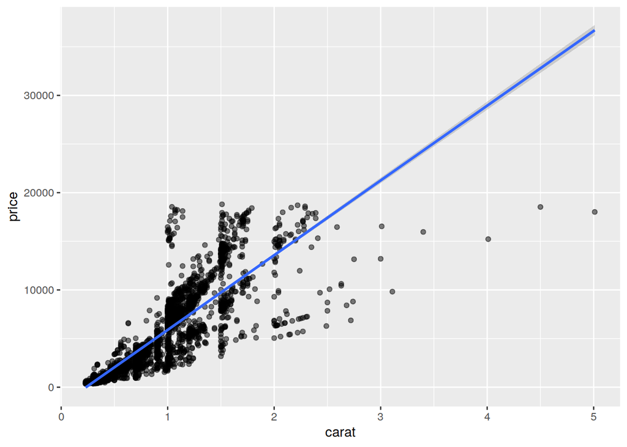

```r
ggplot(diamond_clean, aes(x = carat, y = price)) +
  geom_point(alpha = 0.5) +
  geom_smooth(method = "lm")
```

The relationship between diamond weight (carat) and price is definitely positive, but it doesn’t look linear.

[^2]

##### Color

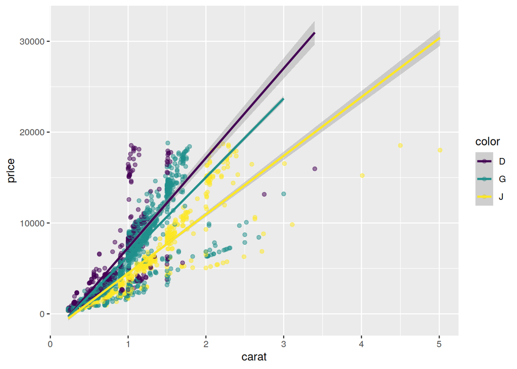

```r
ggplot(diamond_clean, aes(x = carat, y = price, color = color)) +
  geom_point(alpha = 0.5) +
  geom_smooth(method = "lm")
```

All three color groups show a positive relationship between weight and price. The best color (D) has the steepest increase in price, and the worst color (j) has the shallowest price increase.

[^3]

##### Clarity

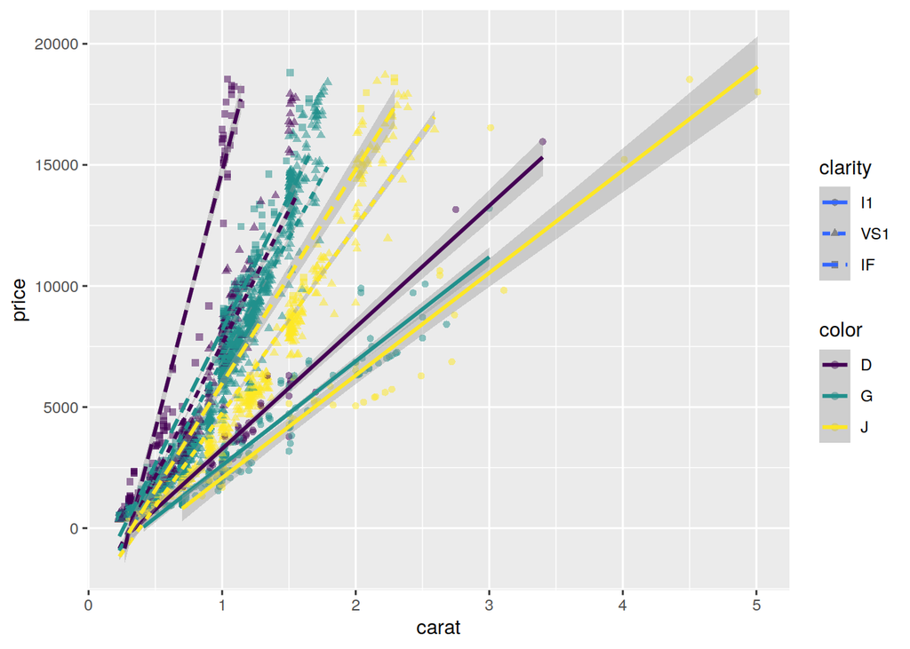

```r
ggplot(diamond_clean, aes(x = carat, y = price, color = color)) +
  geom_point(aes(shape = clarity), alpha = 0.5) +
  geom_smooth(aes(linetype = clarity), method = "lm")
```

The incorporation of diamond clarity provides a lot more information in the plot. In my opinion, there’s so much going on that the plot becomes difficult to read. There are so many lines that it’s a little overwhelming.

[^4]

##### Color and Clarity

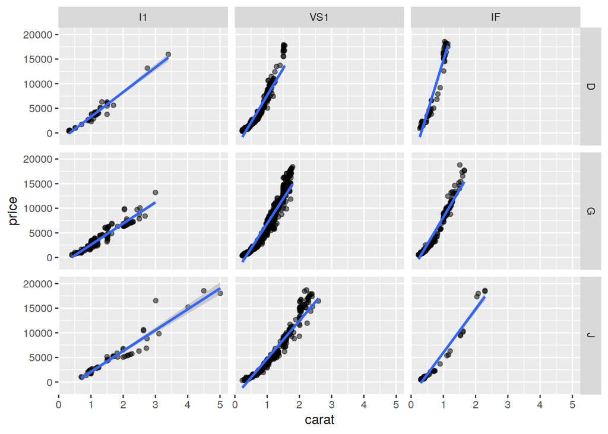

```r
ggplot(diamond_clean, aes(x = carat, y = price)) +
  geom_point(alpha = 0.5) +
  geom_smooth(method = "lm") +
  facet_grid(color ~ clarity)
```

It’s much easier to read the plots with the groups separated. The color-clarity combination with the steepest relationship is D(best) and IF(best).

[^5]

### Numeric Approach

```r
# ppc = Price Per Carat
diamond_clean <- diamond_clean %>% mutate(ppc = price / carat)

diamond_clean %>%
  group_by(color, clarity) %>%
  summarize(avg_ppc = mean(ppc)) %>%
  arrange(desc(avg_ppc)) %>%
  kable()
```

| color | clarity | avg_ppc |
| --- | --- | --- |
| D | IF | 9937.419 |
| G | VS1 | 4420.881 |
| D | VS1 | 4204.891 |
| G | IF | 4007.010 |
| J | VS1 | 3750.351 |
| J | IF | 3220.227 |
| D | I1 | 3064.485 |
| J | I1 | 2710.080 |
| G | I1 | 2617.478 |

The table generally matches the plots well. The combinations with steeper slopes in the plots have higher average price per carat in the table.

[^6]

[^1]: Problem 1 Complete
[^2]: Problem 2 Complete
[^3]: Problem 3 Complete
[^4]: Problem 4 Complete
[^5]: Problem 5 Complete
[^6]: Problem 6 Complete